# Praktikum 2

Bilal Muhammad Thalib

2025-09-01

# Import Library

```r
library("forecast")
```

```r
library("graphics")
library("TTR")
library("TSA")
library(rio)
library(dplyr)
library(ggplot2)
```

# Import Data

```r
data <- import("https://raw.githubusercontent.com/yehezkinovandri/mpdw/7975608dd9ec5128c86261ea6c5a6c2d183fb17f/Pertemuan%201/daily-website-visitors.csv")

head(data)
```

```
##   Row       Day Day.Of.Week      Date Page.Loads Unique.Visits
## 1   1    Sunday           1 9/14/2014      2,146         1,582
## 2   2    Monday           2 9/15/2014      3,621         2,528
## 3   3   Tuesday           3 9/16/2014      3,698         2,630
## 4   4 Wednesday           4 9/17/2014      3,667         2,614
## 5   5  Thursday           5 9/18/2014      3,316         2,366
## 6   6    Friday           6 9/19/2014      2,815         1,863
##   First.Time.Visits Returning.Visits
## 1             1,430              152
## 2             2,297              231
## 3             2,352              278
## 4             2,327              287
## 5             2,130              236
## 6             1,622              241
```

Karena kolom Date masih bertipe character, maka perlu diubah ke tipe Date

```r
library(lubridate)
# ubah dari character ke Date
data$Date <- mdy(data$Date)
```

Karena kolom Page.Loads masih bertipe character, maka perlu diubah ke tipe Numeric

```r
data$Page.Loads <- as.numeric(gsub(",", "", data$Page.Loads))
```

Hanya mengambil kolom Date dan Page.Loads

```r
data <- data %>% select(Date, Page.Loads)
```

Ambil 100 baris dari dataset

```r
data <- data[401:500, ]
data
```

```
##           Date Page.Loads
## 401 2015-10-19       5516
## 402 2015-10-20       5572
## 403 2015-10-21       5243
## 404 2015-10-22       5133
## 405 2015-10-23       4084
## 406 2015-10-24       2739
## 407 2015-10-25       3781
## 408 2015-10-26       5684
## 409 2015-10-27       5687
## 410 2015-10-28       5906
## 411 2015-10-29       5541
## 412 2015-10-30       4171
## 413 2015-10-31       2586
## 414 2015-11-01       3838
```

[output cut: 86 more lines]

# Eksplorasi Data

Cek apakah ada tanggal yang hilang

```r
data$Date <- as.Date(data$Date)
all_dates <- seq(min(data$Date), max(data$Date), by = "day")
missing_dates <- setdiff(all_dates, data$Date)
missing_dates
```

```
## numeric(0)
```

Mengubah data agar terbaca sebagai data deret waktu dengan fungsi

```r
data.ts <- ts(data$Page.Loads)
data.ts
```

```
## Time Series:
## Start = 1
## End = 100
## Frequency = 1
##   [1] 5516 5572 5243 5133 4084 2739 3781 5684 5687 5906 5541 4171 2586 3838 5675
##  [16] 5624 5794 5389 4305 3281 3790 5894 5461 5206 5228 4097 2694 3893 6185 6178
##  [31] 6067 5656 4398 2836 3896 5814 5879 4800 3838 3576 2799 4228 6331 6380 6314
##  [46] 6160 4859 3317 4715 6940 6551 6327 6212 4687 3014 4132 5989 5331 5183 4769
##  [61] 3627 1857 2221 3335 2883 2353 1578 1017 1334 1690 2838 2815 2382 1587 1411
##  [76] 1838 2180 3587 3855 3840 3735 3223 2207 2814 4007 4119 4338 4432 3306 2223
##  [91] 2757 4047 4489 4588 4398 3340 2344 2973 4638 4791
```

Menampilkan ringkasan data

```r
summary(data.ts)
```

```
##    Min. 1st Qu.  Median    Mean 3rd Qu.    Max.
##    1017    2950    4126    4162    5475    6940
```

Menampilkan plot data deret waktu

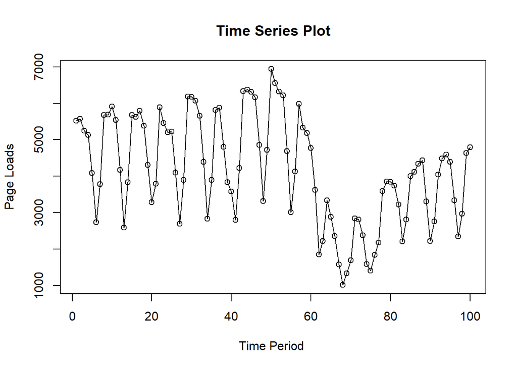

```r
ts.plot(data.ts, xlab="Time Period ", ylab="Page Loads",
        main = "Time Series Plot")
points(data.ts)
```

Data memiliki lonjakan-lonjakan yang dapat diidentifikasi seperti Seasonal sehingga cocok dengan Single Moving Average (SMA) dan Single Exponential Smoothing (SES)

# SIngle Moving Average (SMA)

## Pembagian Data

80% Data Latih (Train) dan 20% Data Uji (Test)

```r
# hitung jumlah data
n <- nrow(data)

# tentukan batas 80%
n_train <- floor(0.8 * n)

# bagi data
training_ma <- data[1:n_train, ]
testing_ma  <- data[(n_train+1):n, ]

# ubah ke time series
train_ma.ts <- ts(training_ma$Page.Loads)
test_ma.ts  <- ts(testing_ma$Page.Loads)
```

Plot data latih

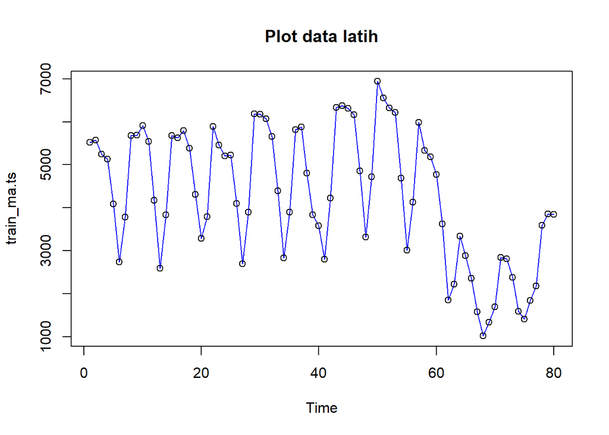

```r
#eksplorasi data latih
plot(train_ma.ts, col="blue",main="Plot data latih")
points(train_ma.ts)
```

Plot data uji

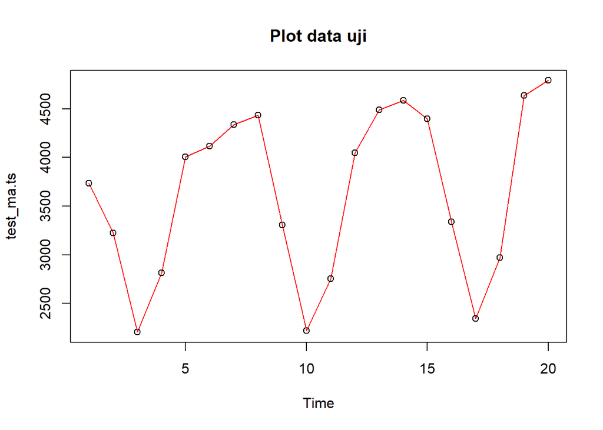

```r
#eksplorasi data uji
plot(test_ma.ts, col="red",main="Plot data uji")
points(test_ma.ts)
```

Plot seluruh data

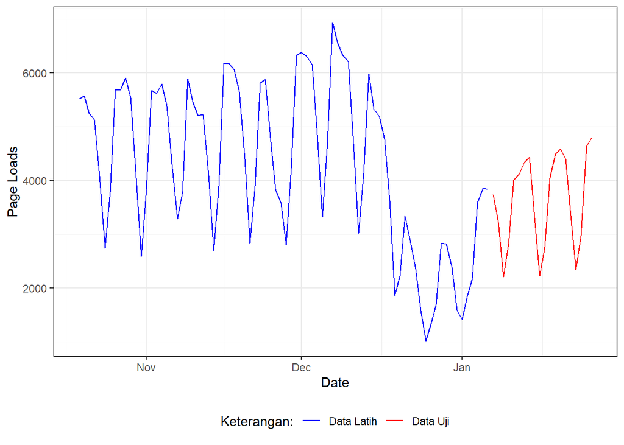

```r
ggplot() +
  geom_line(data = training_ma, aes(x = Date, y = Page.Loads, col = "Data Latih")) +
  geom_line(data = testing_ma, aes(x = Date, y = Page.Loads, col = "Data Uji")) +
  labs(x = "Date", y = "Page Loads", color = "Legend") +
   scale_colour_manual(name="Keterangan:", breaks = c("Data Latih", "Data Uji"),
                      values = c("blue", "red")) +
  theme_bw() + theme(legend.position = "bottom",
                     plot.caption = element_text(hjust=0.5, size=12))
```

```r
data.sma<-SMA(train_ma.ts, n=4)
data.sma
```

```
## Time Series:
## Start = 1
## End = 80
## Frequency = 1
##  [1]      NA      NA      NA 5366.00 5008.00 4299.75 3934.25 4072.00 4472.75
## [10] 5264.50 5704.50 5326.25 4551.00 4034.00 4067.50 4430.75 5232.75 5620.50
## [19] 5278.00 4692.25 4191.25 4317.50 4606.50 5087.75 5447.25 4998.00 4306.25
## [28] 3978.00 4217.25 4737.50 5580.75 6021.50 5574.75 4739.25 4196.50 4236.00
## [37] 4606.25 5097.25 5082.75 4523.25 3753.25 3610.25 4233.50 4934.50 5813.25
## [46] 6296.25 5928.25 5162.50 4762.75 4957.75 5380.75 6133.25 6507.50 5944.25
## [55] 5060.00 4511.25 4455.50 4616.50 5158.75 5318.00 4727.50 3859.00 3118.50
## [64] 2760.00 2574.00 2698.00 2537.25 1957.75 1570.50 1404.75 1719.75 2169.25
## [73] 2431.25 2405.50 2048.75 1804.50 1754.00 2254.00 2865.00 3365.50
```

```r
data.ramal<-c(NA,data.sma)
data.ramal #forecast 1 periode ke depan
```

```
##  [1]      NA      NA      NA      NA 5366.00 5008.00 4299.75 3934.25 4072.00
## [10] 4472.75 5264.50 5704.50 5326.25 4551.00 4034.00 4067.50 4430.75 5232.75
## [19] 5620.50 5278.00 4692.25 4191.25 4317.50 4606.50 5087.75 5447.25 4998.00
## [28] 4306.25 3978.00 4217.25 4737.50 5580.75 6021.50 5574.75 4739.25 4196.50
## [37] 4236.00 4606.25 5097.25 5082.75 4523.25 3753.25 3610.25 4233.50 4934.50
## [46] 5813.25 6296.25 5928.25 5162.50 4762.75 4957.75 5380.75 6133.25 6507.50
## [55] 5944.25 5060.00 4511.25 4455.50 4616.50 5158.75 5318.00 4727.50 3859.00
## [64] 3118.50 2760.00 2574.00 2698.00 2537.25 1957.75 1570.50 1404.75 1719.75
## [73] 2169.25 2431.25 2405.50 2048.75 1804.50 1754.00 2254.00 2865.00 3365.50
```

```r
data.gab<-cbind(
  aktual=c(data.ts),
  pemulusan=c(data.sma,rep(NA,24)),
  ramalan=c(data.ramal,rep(data.ramal[length(data.ramal)],23)))
data.gab #forecast 24 periode ke depan
```

```
##        aktual pemulusan ramalan
##   [1,]   5516        NA      NA
##   [2,]   5572        NA      NA
##   [3,]   5243        NA      NA
##   [4,]   5133   5366.00      NA
##   [5,]   4084   5008.00 5366.00
##   [6,]   2739   4299.75 5008.00
##   [7,]   3781   3934.25 4299.75
##   [8,]   5684   4072.00 3934.25
##   [9,]   5687   4472.75 4072.00
##  [10,]   5906   5264.50 4472.75
##  [11,]   5541   5704.50 5264.50
##  [12,]   4171   5326.25 5704.50
##  [13,]   2586   4551.00 5326.25
##  [14,]   3838   4034.00 4551.00
```

[output cut: 90 more lines]

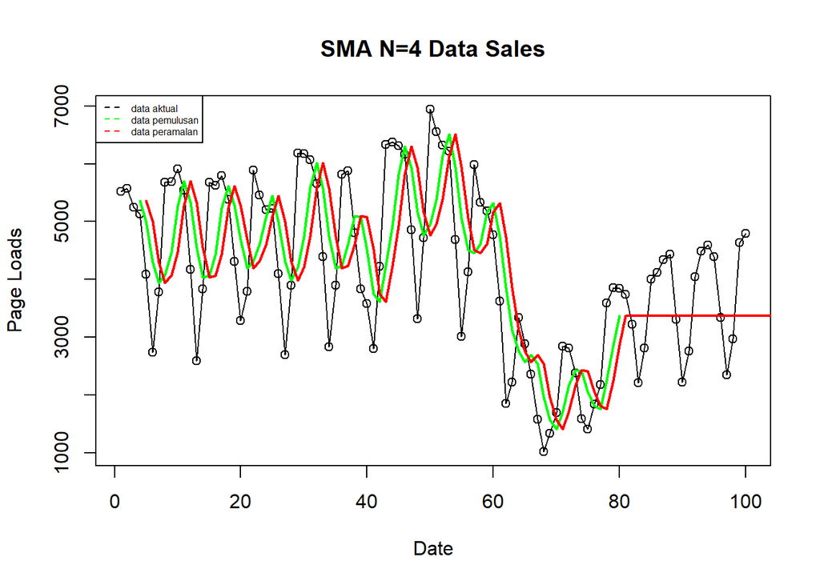

```r
ts.plot(data.ts, xlab="Date", ylab="Page Loads", main= "SMA N=4 Data Sales")
points(data.ts)
lines(data.gab[,2],col="green",lwd=2)
lines(data.gab[,3],col="red",lwd=2)
legend("topleft",c("data aktual","data pemulusan","data peramalan"), lty=8, col=c("black","green","red"), cex=0.5)
```

```r
#Menghitung nilai keakuratan data latih
error_train.sma = train_ma.ts-data.ramal[1:length(train_ma.ts)]

SSE_train.sma = sum(error_train.sma[5:length(train_ma.ts)]^2)
MSE_train.sma = mean(error_train.sma[5:length(train_ma.ts)]^2)
MAPE_train.sma = mean(abs((error_train.sma[5:length(train_ma.ts)]/train_ma.ts[5:length(train_ma.ts)])*100))

akurasi_train.sma <- matrix(c(SSE_train.sma, MSE_train.sma, MAPE_train.sma))
row.names(akurasi_train.sma)<- c("SSE", "MSE", "MAPE")
colnames(akurasi_train.sma) <- c("Akurasi m = 4")
akurasi_train.sma
```

```
##      Akurasi m = 4
## SSE   1.617989e+08
## MSE   2.128933e+06
## MAPE  3.517233e+01
```

```r
# Ambil data aktual (baris 50-88, kolom 1)
actual_test <- data.gab[50:88, 1]

# Ambil data ramalan (baris 50-88, kolom 3)
forecast_test <- data.gab[50:88, 3]

# Hitung error
error_test.sma <- actual_test - forecast_test

# Hitung metrik
SSE_test.sma <- sum(error_test.sma^2)
MSE_test.sma <- mean(error_test.sma^2)
MAPE_test.sma <- mean(abs(error_test.sma / actual_test * 100))

# Simpan dalam matrix
akurasi_test.sma <- matrix(c(SSE_test.sma, MSE_test.sma, MAPE_test.sma))
row.names(akurasi_test.sma) <- c("SSE", "MSE", "MAPE")
colnames(akurasi_test.sma) <- c("Akurasi m = 4")

akurasi_test.sma
```

```
##      Akurasi m = 4
## SSE   5.915287e+07
## MSE   1.516740e+06
## MAPE  3.579362e+01
```

# Single Exponential Smoothing (SES)

## Pembagian Data

80% Data Latih (Train) dan 20% Data Uji (Test)

```r
# jumlah baris data
n <- nrow(data)

# hitung batas 80%
n_train <- floor(0.8 * n)

# bagi data
training <- data[1:n_train, ]
testing  <- data[(n_train+1):n, ]

# ubah ke time series
train.ts <- ts(training$Page.Loads)
test.ts  <- ts(testing$Page.Loads)
```

Plot data train

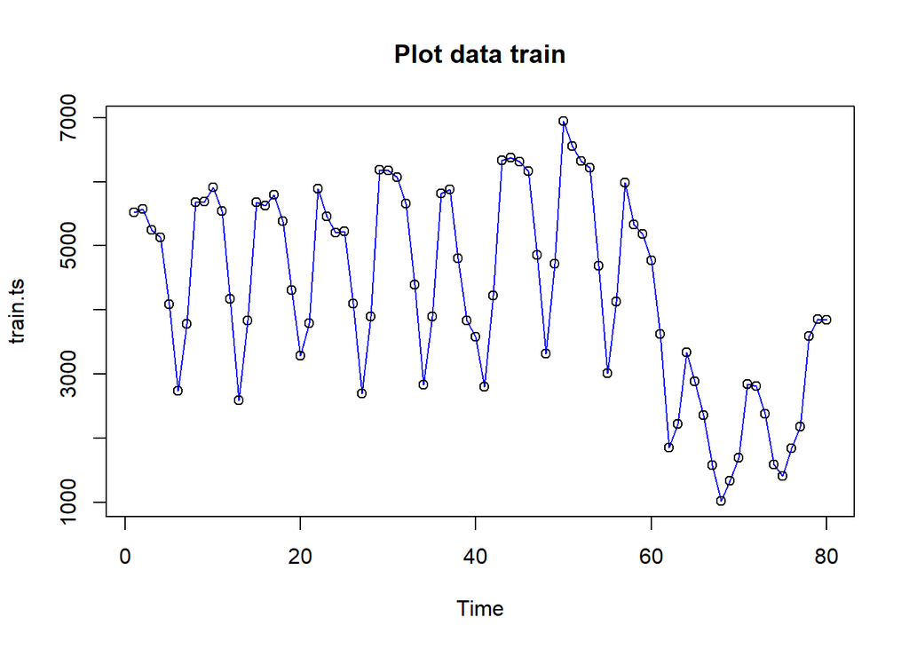

```r
plot(train.ts, col="blue",main="Plot data train")
points(train.ts)
```

Plot data test

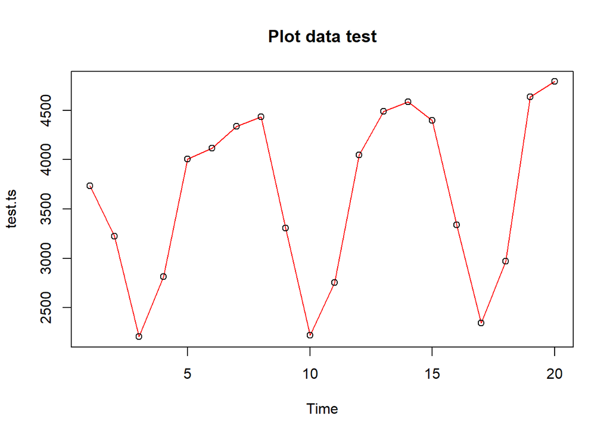

```r
plot(test.ts, col="red",main="Plot data test")
points(test.ts)
```

Plot seluruh data

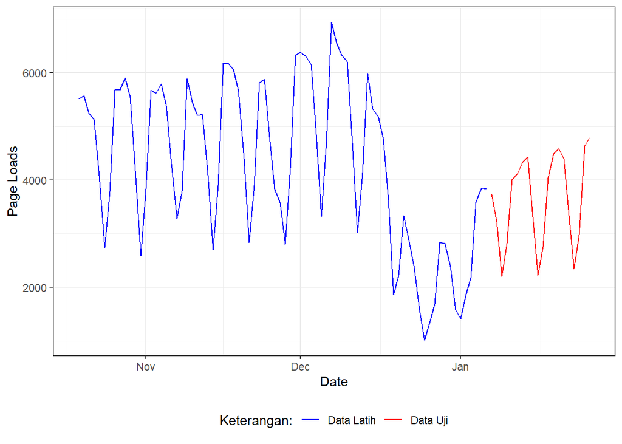

```r
ggplot() +
  geom_line(data = training, aes(x = Date, y = Page.Loads, col = "Data Latih")) +
  geom_line(data = testing, aes(x = Date, y = Page.Loads, col = "Data Uji")) +
  labs(x = "Date", y = "Page Loads", color = "Legend") +
  scale_colour_manual(name="Keterangan:", breaks = c("Data Latih", "Data Uji"),
                      values = c("blue", "red")) +
  theme_bw() + theme(legend.position = "bottom",
                     plot.caption = element_text(hjust=0.5, size=12))
```

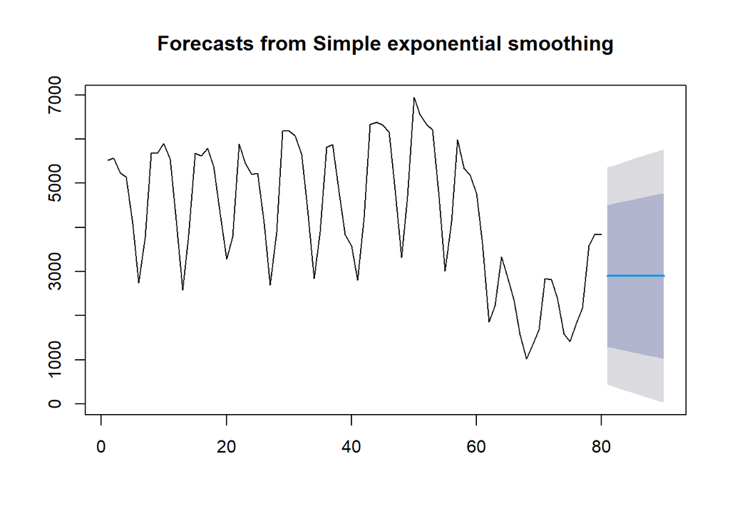

```r
#Cara 1 (fungsi ses)
ses.1 <- ses(train.ts, h = 10, alpha = 0.2)
plot(ses.1)
```

```r
ses.1
```

```
##    Point Forecast    Lo 80    Hi 80     Lo 95    Hi 95
## 81        2899.93 1295.142 4504.718 445.61867 5354.242
## 82        2899.93 1263.361 4536.499 397.01373 5402.847
## 83        2899.93 1232.186 4567.675 349.33484 5450.526
## 84        2899.93 1201.582 4598.278 302.53102 5497.329
## 85        2899.93 1171.521 4628.340 256.55579 5543.305
## 86        2899.93 1141.973 4657.887 211.36662 5588.494
## 87        2899.93 1112.914 4686.947 166.92455 5632.936
## 88        2899.93 1084.320 4715.541 123.19368 5676.667
## 89        2899.93 1056.169 4743.691  80.14093 5719.720
## 90        2899.93 1028.442 4771.419  37.73570 5762.125
```

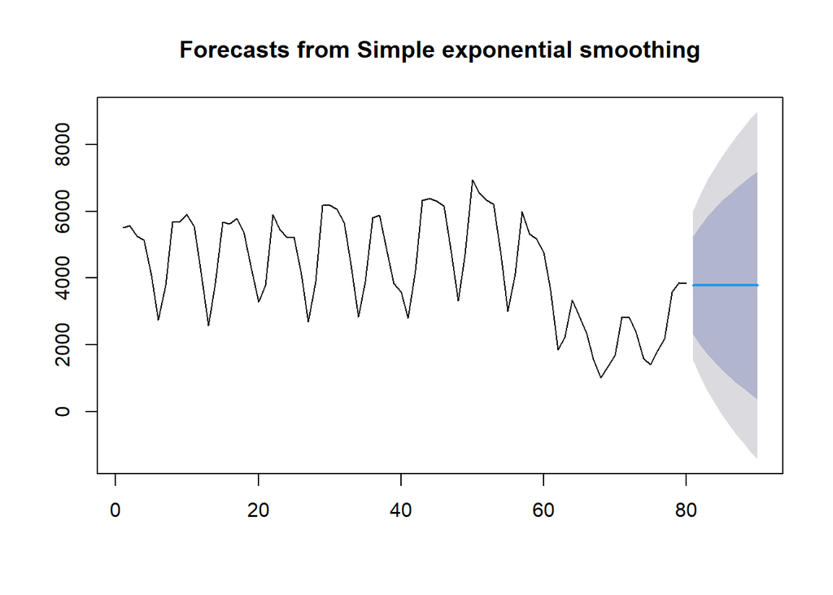

```r
ses.2<- ses(train.ts, h = 10, alpha = 0.7)
plot(ses.2)
```

```r
ses.2
```

```
##    Point Forecast     Lo 80    Hi 80       Lo 95    Hi 95
## 81       3778.907 2313.5291 5244.284  1537.80503 6020.009
## 82       3778.907 1990.1854 5567.628  1043.29346 6514.520
## 83       3778.907 1716.9376 5840.876   625.39709 6932.416
## 84       3778.907 1475.8850 6081.929   256.73890 7301.075
## 85       3778.907 1257.7757 6300.038   -76.83047 7634.644
## 86       3778.907 1057.0886 6500.725  -383.75497 7941.569
## 87       3778.907  870.2152 6687.598  -669.55318 8227.367
## 88       3778.907  694.6436 6863.170  -938.06674 8495.880
## 89       3778.907  528.5419 7029.272 -1192.09738 8749.911
## 90       3778.907  370.5253 7187.288 -1433.76293 8991.576
```

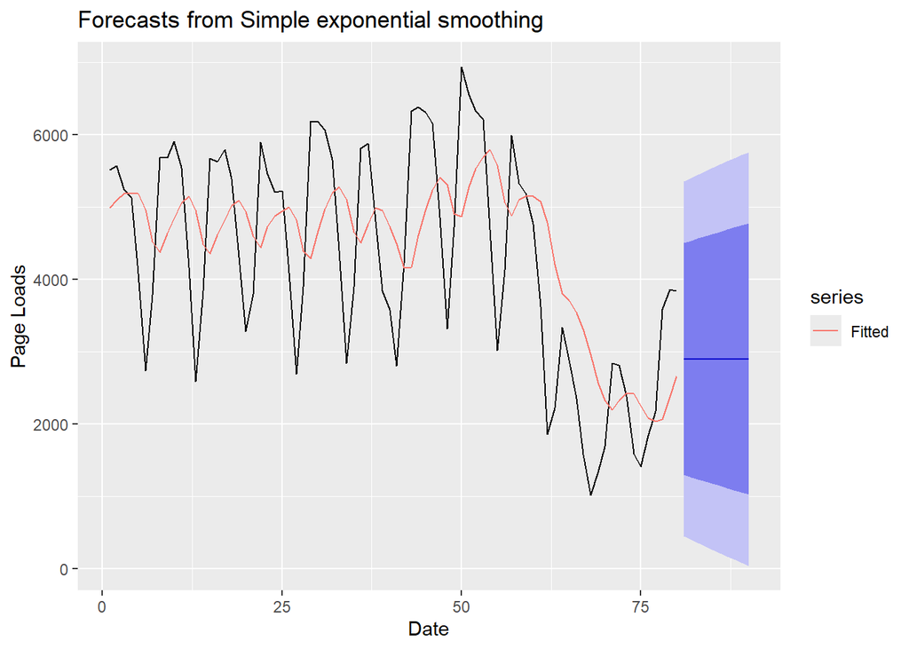

```r
autoplot(ses.1) +
  autolayer(fitted(ses.1), series="Fitted") +
  ylab("Page Loads") + xlab("Date")
```

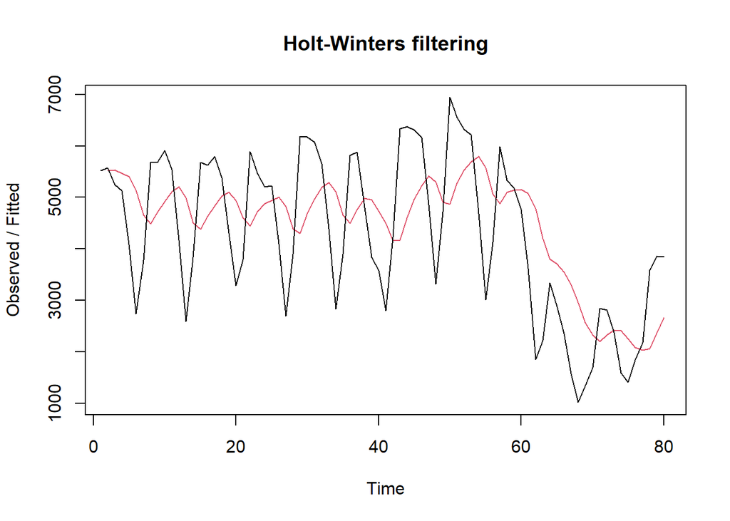

```r
#Cara 2 (fungsi Holtwinter)
ses1<- HoltWinters(train.ts, gamma = FALSE, beta = FALSE, alpha = 0.2)
plot(ses1)
```

```r
#ramalan
ramalan1<- forecast(ses1, h=10)
ramalan1
```

```
##    Point Forecast    Lo 80    Hi 80     Lo 95    Hi 95
## 81        2899.93 1304.277 4495.583 459.58950 5340.271
## 82        2899.93 1272.677 4527.183 411.26123 5388.599
## 83        2899.93 1241.679 4558.182 363.85375 5436.007
## 84        2899.93 1211.250 4588.611 317.31636 5482.544
## 85        2899.93 1181.359 4618.501 271.60283 5528.258
## 86        2899.93 1151.980 4647.881 226.67090 5573.190
## 87        2899.93 1123.086 4676.774 182.48180 5617.379
## 88        2899.93 1094.655 4705.206 138.99987 5660.861
## 89        2899.93 1066.664 4733.196  96.19219 5703.668
## 90        2899.93 1039.095 4760.765  54.02835 5745.832
```

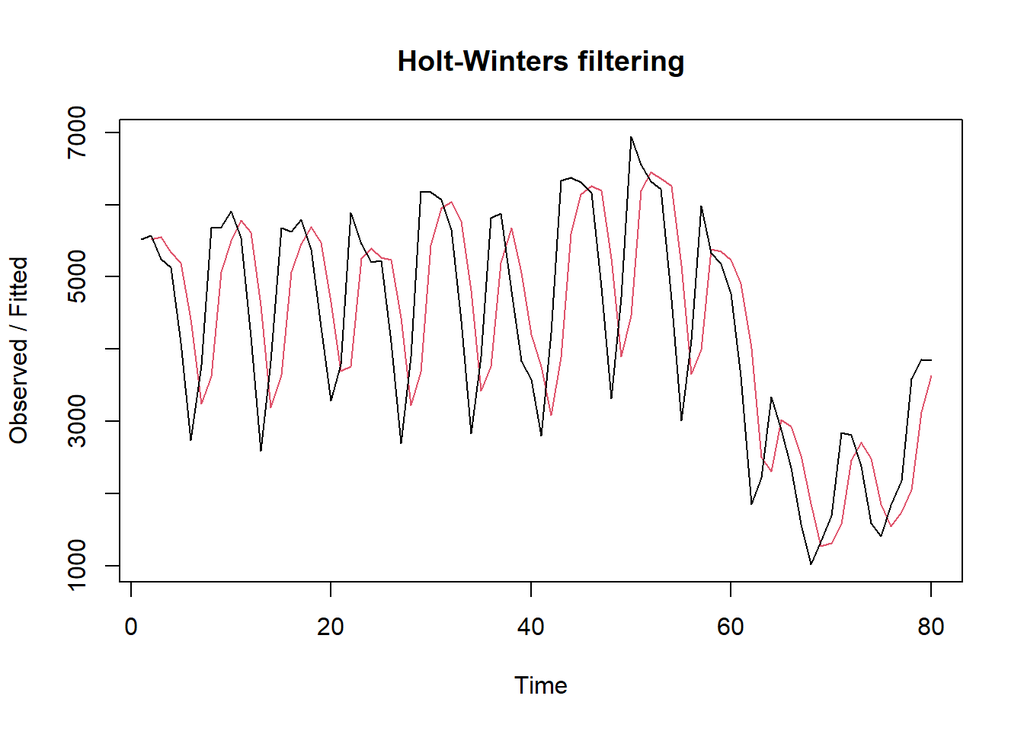

```r
ses2<- HoltWinters(train.ts, gamma = FALSE, beta = FALSE, alpha = 0.7)
plot(ses2)
```

```r
#ramalan
ramalan2<- forecast(ses2, h=10)
ramalan2
```

```
##    Point Forecast     Lo 80    Hi 80       Lo 95    Hi 95
## 81       3778.907 2314.1138 5243.700  1538.69926 6019.114
## 82       3778.907 1990.8991 5566.914  1044.38501 6513.429
## 83       3778.907 1717.7604 5840.053   626.65538 6931.158
## 84       3778.907 1476.8039 6081.010   258.14430 7299.669
## 85       3778.907 1258.7817 6299.032   -75.29197 7633.106
## 86       3778.907 1058.1746 6499.639  -382.09401 7939.908
## 87       3778.907  871.3758 6686.438  -667.77819 8225.592
## 88       3778.907  695.8742 6861.939  -936.18460 8493.998
## 89       3778.907  529.8388 7027.975 -1190.11388 8747.927
## 90       3778.907  371.8852 7185.928 -1431.68301 8989.497
```

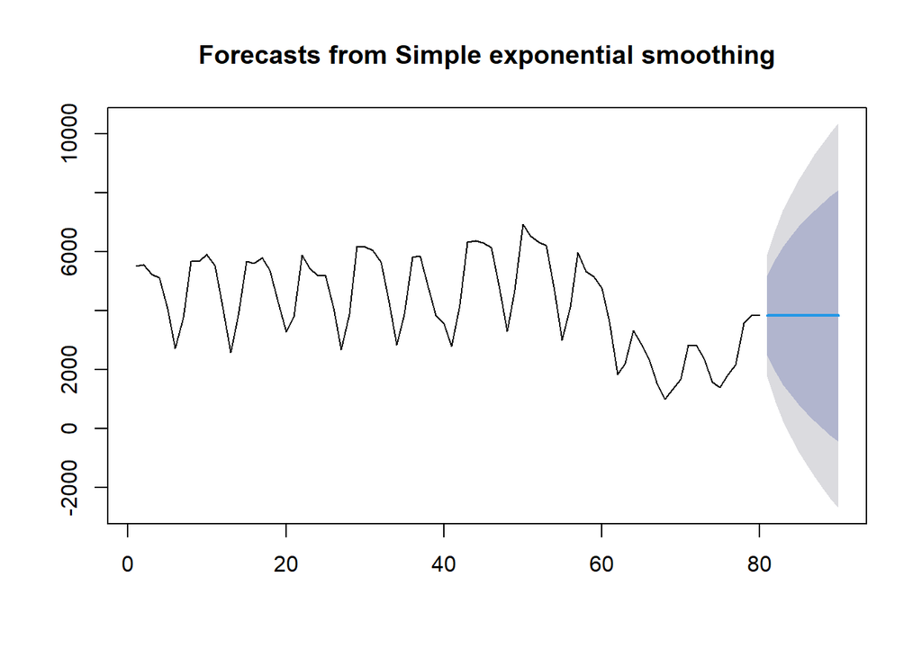

```r
#SES
ses.opt <- ses(train.ts, h = 10, alpha = NULL)
plot(ses.opt)
```

```r
ses.opt
```

```
##    Point Forecast      Lo 80    Hi 80      Lo 95     Hi 95
## 81       3840.001 2488.88397 5191.119  1773.6455  5906.357
## 82       3840.001 1929.32830 5750.675   917.8790  6762.124
## 83       3840.001 1499.95330 6180.050   261.2066  7418.796
## 84       3840.001 1137.96910 6542.034  -292.4004  7972.403
## 85       3840.001  819.05255 6860.950  -780.1412  8460.144
## 86       3840.001  530.72876 7149.274 -1221.0944  8901.097
## 87       3840.001  265.58692 7414.416 -1626.5939  9306.597
## 88       3840.001   18.79841 7661.205 -2004.0243  9684.027
## 89       3840.001 -212.99080 7892.994 -2358.5153 10038.518
## 90       3840.001 -432.22275 8112.226 -2693.8017 10373.805
```

```r
#Lamda Optimum Holt Winter
HWopt<- HoltWinters(train.ts, gamma = FALSE, beta = FALSE,alpha = NULL)
HWopt
```

```
## Holt-Winters exponential smoothing without trend and without seasonal component.
##
## Call:
## HoltWinters(x = train.ts, alpha = NULL, beta = FALSE, gamma = FALSE)
##
## Smoothing parameters:
##  alpha: 0.9999339
##  beta : FALSE
##  gamma: FALSE
##
## Coefficients:
##       [,1]
## a 3840.001
```

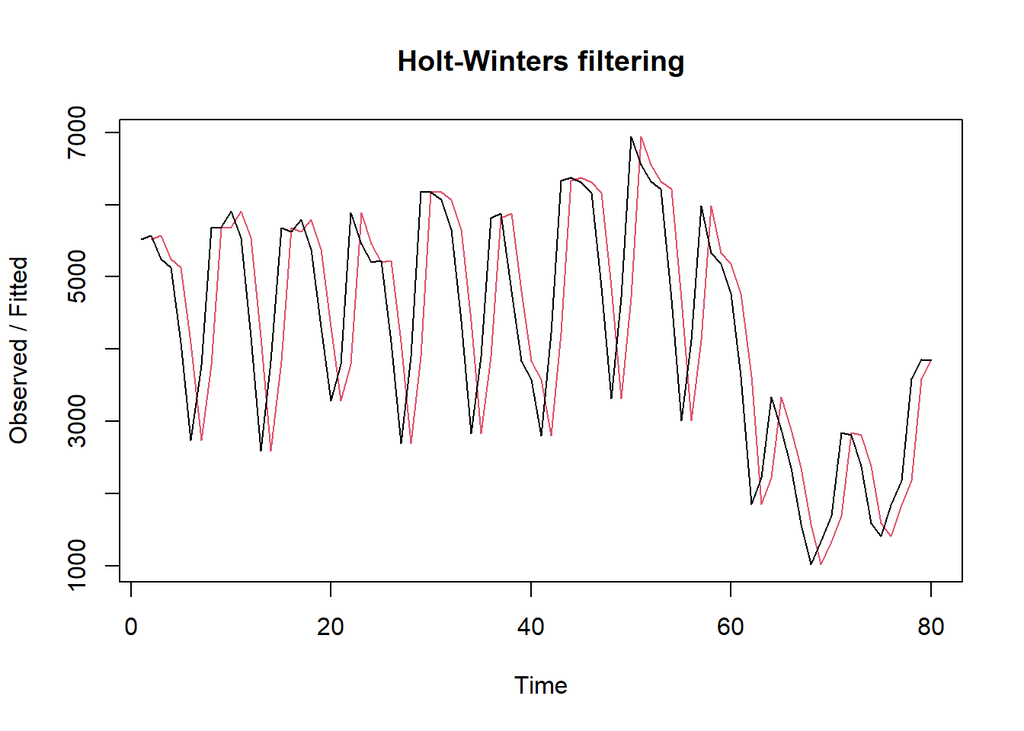

```r
plot(HWopt)
```

```r
#ramalan
ramalanopt<- forecast(HWopt, h=10)
ramalanopt
```

```
##    Point Forecast      Lo 80    Hi 80      Lo 95     Hi 95
## 81       3840.001 2491.35083 5188.651  1777.4186  5902.583
## 82       3840.001 1932.78469 5747.217   923.1654  6756.837
## 83       3840.001 1504.17334 6175.829   267.6609  7412.341
## 84       3840.001 1142.83441 6537.168  -284.9593  7964.961
## 85       3840.001  824.48704 6855.515  -771.8296  8451.832
## 86       3840.001  536.67825 7143.324 -1211.9952  8891.997
## 87       3840.001  272.01025 7407.992 -1616.7700  9296.772
## 88       3840.001   25.66295 7654.339 -1993.5256  9673.528
## 89       3840.001 -205.71174 7885.714 -2347.3827 10027.385
## 90       3840.001 -424.55154 8104.554 -2682.0693 10362.071
```

Akurasi data latih

```r
#Keakuratan Metode
#Pada data training

# SES dengan alpha = 0.2
SSE1<-ses1$SSE
MSE1<-ses1$SSE/length(train.ts)
RMSE1<-sqrt(MSE1)

akurasi1 <- matrix(c(SSE1,MSE1,RMSE1))
row.names(akurasi1)<- c("SSE", "MSE", "RMSE")
colnames(akurasi1) <- c("Akurasi lamda=0.2")
akurasi1
```

```
##      Akurasi lamda=0.2
## SSE       1.230861e+08
## MSE       1.538576e+06
## RMSE      1.240394e+03
```

```r
# SES dengan alpha = 0.7
SSE2<-ses2$SSE
MSE2<-ses2$SSE/length(train.ts)
RMSE2<-sqrt(MSE2)

akurasi2 <- matrix(c(SSE2,MSE2,RMSE2))
row.names(akurasi2)<- c("SSE", "MSE", "RMSE")
colnames(akurasi2) <- c("Akurasi lamda=0.7")
akurasi2
```

```
##      Akurasi lamda=0.7
## SSE       1.019781e+08
## MSE       1.274727e+06
## RMSE      1.129038e+03
```

```r
# jumlah observasi uji
n_test <- nrow(testing)

# error (ramalan - aktual), samakan panjang dan tipe numeric
e1   <- as.numeric(ramalan1$mean)[1:n_test] - as.numeric(testing$Page.Loads)
e2   <- as.numeric(ramalan2$mean)[1:n_test] - as.numeric(testing$Page.Loads)
eopt <- as.numeric(ramalanopt$mean)[1:n_test] - as.numeric(testing$Page.Loads)

# SSE / MSE / RMSE untuk masing-masing model (abaikan NA)
SSEtesting1  <- sum(e1^2,  na.rm = TRUE)
MSEtesting1  <- mean(e1^2, na.rm = TRUE)
RMSEtesting1 <- sqrt(MSEtesting1)

SSEtesting2  <- sum(e2^2,  na.rm = TRUE)
MSEtesting2  <- mean(e2^2, na.rm = TRUE)
RMSEtesting2 <- sqrt(MSEtesting2)

SSEtestingopt  <- sum(eopt^2,  na.rm = TRUE)
MSEtestingopt  <- mean(eopt^2, na.rm = TRUE)
RMSEtestingopt <- sqrt(MSEtestingopt)

# Tabel ringkas
akurasitesting_SSE <- matrix(c(SSEtesting1, SSEtesting2, SSEtestingopt),
                             nrow = 3,
                             dimnames = list(c("SSE1","SSE2","SSEopt"), "Nilai"))
akurasitesting_MSE <- matrix(c(MSEtesting1, MSEtesting2, MSEtestingopt),
                             nrow = 3,
                             dimnames = list(c("MSE1","MSE2","MSEopt"), "Nilai"))
akurasitesting_RMSE <- matrix(c(RMSEtesting1, RMSEtesting2, RMSEtestingopt),
                              nrow = 3,
                              dimnames = list(c("RMSE1","RMSE2","RMSEopt"), "Nilai"))

akurasitesting_SSE
```

```
##          Nilai
## SSE1   9039396
## SSE2   7264189
## SSEopt 7715130
```

Dari sini: SSE1 > SSE2, artinya model 2 lebih baik daripada model 1

```r
akurasitesting_MSE
```

```
##           Nilai
## MSE1   903939.6
## MSE2   726418.9
## MSEopt 771513.0
```

Hasilnya sama, MSE1 > MSE2, artinya model 2 lebih baik daripada model 1

```r
akurasitesting_RMSE
```

```
##            Nilai
## RMSE1   950.7574
## RMSE2   852.3021
## RMSEopt 878.3581
```

Hasilnya sama, RMSE1 > RMSE2, artinya model 2 lebih baik daripada model 1 dengan rata-rata error per prediksi sekitar 852 Page Loads.

Model 1 jauh lebih buruk (error rata-rata sekitar 950).

# Kesimpulan

Model 2 memberikan hasil terbaik (error paling kecil).

Model 1 jelas lebih buruk (SSE, MSE, RMSE lebih besar).

Model optimal (SSEopt/MSEopt/RMSEopt) hampir sama dengan Model 2, artinya tuning parameter tidak banyak memperbaiki performa → Model 2 sudah cukup baik.

Dari sudut pandang praktis, model terbaik menghasilkan error rata-rata sekitar 852 Page Loads per periode.